# Comparison of Sex Ratio

**This project deals with the exploratory analysis of the NFHS-3 and NFHS-4 data set by setting out research questions, and then exploring relationship between variables to answer those questions.**

This analysis is done on the data set collected from all the states of INDIA through **NFHS-3(2005-2006)** and **NFHS-4(2015-2016)** ,which was recently released by Ministery of health and family.This report offers a comprehensive picture of the health, literacy and population status in all 29 states of the country. It paints a mixed picture of India’s overall reproductive health status. On the other hand, women are having fewer children and infant mortality has dropped in the seven-year period since the last NFHS survey in 1998-99.

The NFHS survey is based on a sample of households that is representative at the national and state levels. It conducted interviews with around 2,00,000 women age 15-49 and men age 15-54 throughout India.The data set on key indicators provides a trend that includes information on several new topics, such as literacy rate,sanitation, health problems, related attitudes and behaviour, male involvement in family welfare and attitudes about family life and education for children in school.

## Part 1: Data Set

#### Load packages

```r
library(ggplot2)
library(dplyr)
```

#### Load data

```r
myData <- read.csv(file='C:\\Users\\Shivang Keshari\\Downloads\\multi\\myFile.csv', header=TRUE)

myData <- myData %>%
mutate(Sex_rat_perc_male = (1000/(1000+Sex_ratio_all))*100)

myData <- myData %>%
mutate(Sex_rat_perc_female = (Sex_ratio_all/(1000+Sex_ratio_all))*100)

myData <- myData %>%
mutate(more_male = Sex_rat_perc_male > Sex_rat_perc_female)

myData_tot <- myData %>%
filter(Area == "Total")

myData_tot_nna <- myData_tot %>%
filter(!is.na(Sex_ratio_all))

myData_tot_stat <- myData_tot_nna %>%
filter(India.States.UTs!="India")

myData_tot_stat_n3 <- myData_tot_stat %>% filter(Survey=="NFHS-3")

myData_tot_stat_n4 <- myData_tot_stat %>% filter(Survey=="NFHS-4")
```

## Part 2: Research Questions

**Research question 1:** How does the sex ratio in India in NFHS-4 has been affected when compared from the past record of NFHS-3 by providing necessary awareness about the pros and cons of having more children per family?

## Part 3: Data Analysis

**Interrogation 1:** How does the sex ratio in India in NFHS-4 has been affected when compared from the past record of NFHS-3 by providing necessary awareness about the pros and cons of having more children per family?

**SIGNIFICANCE**

It provides with the basic knowledge about the day-to-day awareness brought in by the government schemes in order to change the mindset of the less educated people regarding the family planning . “Mother”- the sole member of the family is also getting sufficient information about her physical and mental behavior on having more babies through unbothered sex.

```r
myData_tot_stat_n3 %>%
   summarise(mean_dd = mean(Sex_ratio_all), sd_dd = sd(Sex_ratio_all), n = n())
```

```
##    mean_dd    sd_dd  n
## 1 994.1071 66.31482 28
```

**EXPLAINATION**

The “Histogram” below shows the maximum sex ratio at count 1000 , which means that the maximum number of states in NFHS-3 certainly has good conditions but not overall.

STATISTICAL VALUES:- MEAN=994.107 STANDARD DEVIATION=66.314

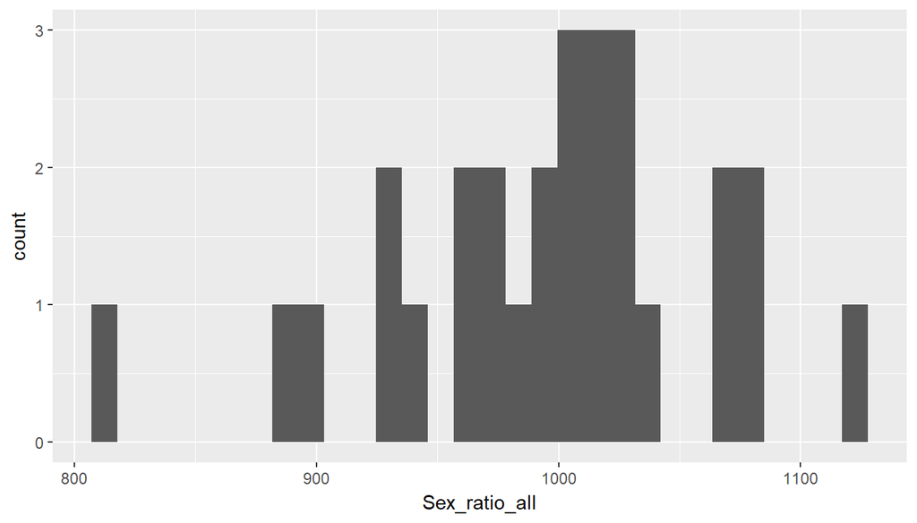

```r
ggplot(data = myData_tot_stat_n3, aes(x = Sex_ratio_all)) +    geom_histogram()
```

```r
myData_tot_stat_n4 %>%
   summarise(mean_dd = mean(Sex_ratio_all), sd_dd = sd(Sex_ratio_all), n = n())
```

```
##    mean_dd    sd_dd  n
## 1 980.1111 69.55359 36
```

**EXPLAINATION**

STATISTICAL VALUES:- MEAN=980.111 STANDARD DEVIATION=69.553

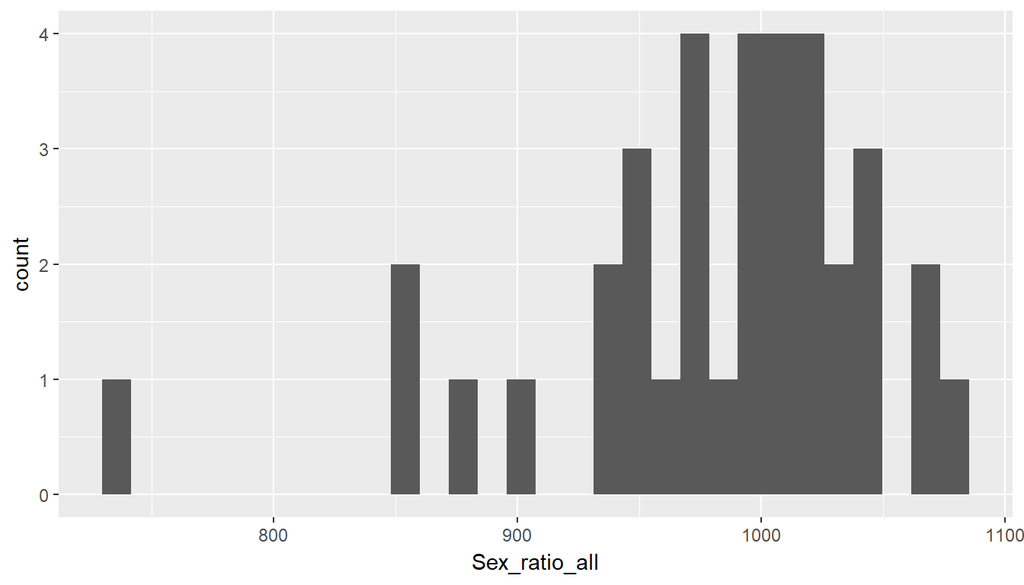

```r
ggplot(data = myData_tot_stat_n4, aes(x = Sex_ratio_all)) +    geom_histogram()
```

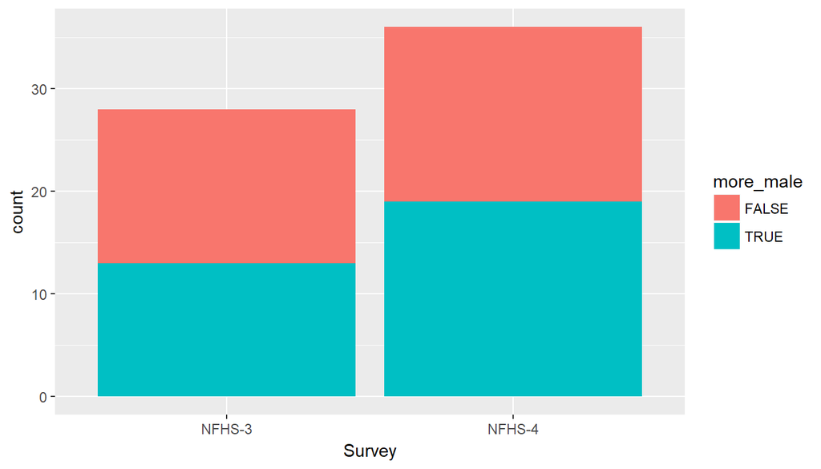

```r
ggplot(data = myData_tot_stat, aes(x = Survey, fill = more_male)) +
  geom_bar()
```

**EXPLAINATION**